# EloyBravo-PRAn

## Accidentes de tráfico de la Ciudad de Madrid (desde 2019)

Accidentes de tráfico en la Ciudad de Madrid registrados por Policía Municipal con víctimas y/o daños al patrimonio, esta conjunto de datos nos permitira conocer por distritos de la ciudad de Madrid que tipo de accidentes ocurren con más frecuencia y les permitira a las autoridades tomar cartas en el asunto para reducirle el numero de accidentes.

## Valores NA por Variables

```r
row.has.na <- sapply(Datos[,1:13], function(x) sum(is.na(x)))
row.has.na
```

```
##       Nº  EXPEDIENTE                FECHA                 HORA
##                    0                    0                    0
##                CALLE               NÚMERO             DISTRITO
##                    0                    0                    0
##       TIPO ACCIDENTE ESTADO METEREOLÓGICO        TIPO VEHÍCULO
##                   27                 2498                  125
##         TIPO PERSONA        RANGO DE EDAD                 SEXO
##                   25                    0                 3007
##           LESIVIDAD*
##                11513
```

## Eliminando NA (DISTRITO y TIPO ACCIDENTE )

```r
datos2<-Datos[!is.na(Datos$`TIPO ACCIDENTE`),]
datos2<-datos2[!is.na(datos2$DISTRITO),]

row.has.na2 <- sapply(datos2[,1:13], function(x) sum(is.na(x)))
row.has.na2
```

```
##       Nº  EXPEDIENTE                FECHA                 HORA
##                    0                    0                    0
##                CALLE               NÚMERO             DISTRITO
##                    0                    0                    0
##       TIPO ACCIDENTE ESTADO METEREOLÓGICO        TIPO VEHÍCULO
##                    0                 2471                  105
##         TIPO PERSONA        RANGO DE EDAD                 SEXO
##                    5                    0                 2986
##           LESIVIDAD*
##                11490
```

Se procedio a limpiar la base de datos debido a que habían registros en blancos para las variables que vamos a utilizar en el proceso PCA en este caso las variables Distrito y Tipo Accidente, se eliminaron los registros vacios para una de las dos variables o ambas.

## Tabla Cruzada Tipo de Acidente vs Distrito

```r
Tabla<-datos2 %>%
        select(`TIPO ACCIDENTE`, DISTRITO) %>%
        table()

Tabla
```

```
##                               DISTRITO
## TIPO ACCIDENTE                 ARGANZUELA BARAJAS CARABANCHEL CENTRO CHAMARTÍN
##   Alcance                             292      64         350    265       418
##   Atropello a animal                    0       2           7      0         4
##   Atropello a persona                  69      27         163     93        84
##   Caída                                83      23          73    110       111
##   Choque contra obstáculo fijo        120      94         273    106       209
##   Colisión frontal                      8      22          40     34        21
##   Colisión fronto-lateral             233     109         374    244       341
##   Colisión lateral                    142      70         166    221       315
##   Colisión múltiple                    83      19         124     37        65
##   Despeñamiento                         0       0           0      0         1
##   Otro                                 24      21          37     76        42
##   Solo salida de la vía                 0       2           0      1         1
##   Vuelco                                0       0           8      0         1
##                               DISTRITO
## TIPO ACCIDENTE                 CHAMBERÍ CIUDAD LINEAL FUENCARRAL-EL PARDO
##   Alcance                           204           350                 325
##   Atropello a animal                  0             7                   7
##   Atropello a persona                74            77                  90
##   Caída                             135            83                  87
##   Choque contra obstáculo fijo      107           238                 253
##   Colisión frontal                   11            26                  35
##   Colisión fronto-lateral           350           480                 313
##   Colisión lateral                  150           168                 163
##   Colisión múltiple                  58           147                  85
##   Despeñamiento                       0             0                   0
##   Otro                               56            93                  45
##   Solo salida de la vía               1             3                  10
##   Vuelco                              4            12                   4
##                               DISTRITO
## TIPO ACCIDENTE                 HORTALEZA LATINA MONCLOA-ARAVACA MORATALAZ
##   Alcance                            137    236             317       198
##   Atropello a animal                   5      4               2         2
##   Atropello a persona                 84     91              58        38
##   Caída                               71     66             114        39
##   Choque contra obstáculo fijo       222    239             202       117
##   Colisión frontal                   138     19              42         6
##   Colisión fronto-lateral            371    284             288       160
##   Colisión lateral                   150    144             140        90
```

[output cut: 35 more lines]

```
##                               DISTRITO
## TIPO ACCIDENTE                 VILLA DE VALLECAS VILLAVERDE
##   Alcance                                    113        121
##   Atropello a animal                           0          2
##   Atropello a persona                         63         74
##   Caída                                       36         24
##   Choque contra obstáculo fijo               106        130
##   Colisión frontal                            14         18
##   Colisión fronto-lateral                    232        178
##   Colisión lateral                           115         97
##   Colisión múltiple                           34         70
##   Despeñamiento                                0          0
##   Otro                                        44         40
##   Solo salida de la vía                        6          3
##   Vuelco                                       3         16
```

## Distribuciones- número de Accidentes por Distritos

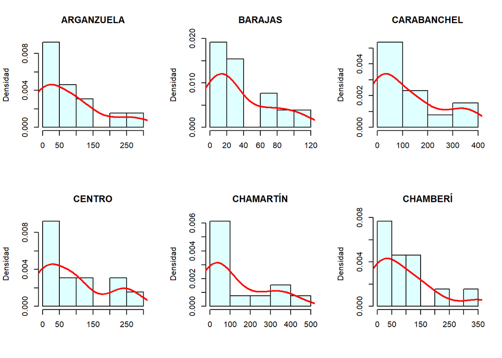

```r
par(mfrow=c(2,3))


hist(pca$ARGANZUELA,freq = FALSE,col = "lightcyan",main = "ARGANZUELA",xlab="",ylab="Densidad")
lines(density(pca$ARGANZUELA),col="red",lwd=2)


hist(pca$BARAJAS,freq = FALSE,col = "lightcyan",main = "BARAJAS",xlab="",ylab="Densidad")
lines(density(pca$BARAJAS),col="red",lwd=2)


hist(pca$CARABANCHEL,freq = FALSE,col = "lightcyan",main = "CARABANCHEL",xlab="",ylab="Densidad")
lines(density(pca$CARABANCHEL),col="red",lwd=2)


hist(pca$CENTRO,freq = FALSE,col = "lightcyan",main = "CENTRO",xlab="",ylab="Densidad")
lines(density(pca$CENTRO),col="red",lwd=2)



hist(pca$CHAMARTÍN,freq = FALSE,col = "lightcyan",main = "CHAMARTÍN",xlab="",ylab="Densidad")
lines(density(pca$CHAMARTÍN),col="red",lwd=2)

hist(pca$CHAMBERÍ,freq = FALSE,col = "lightcyan",main = "CHAMBERÍ",xlab="",ylab="Densidad")
lines(density(pca$CHAMBERÍ),col="red",lwd=2)
```

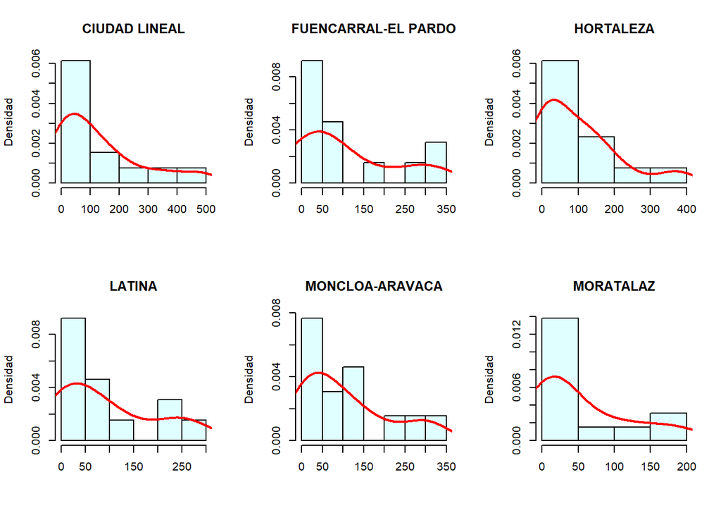

```r
par(mfrow=c(2,3))
hist(pca$`CIUDAD LINEAL`,freq = FALSE,col = "lightcyan",main = "CIUDAD LINEAL",xlab="",ylab="Densidad")
lines(density(pca$`CIUDAD LINEAL`),col="red",lwd=2)

hist(pca$`FUENCARRAL-EL PARDO`,freq = FALSE,col = "lightcyan",main = "FUENCARRAL-EL PARDO",xlab="",ylab="Densidad")
lines(density(pca$`FUENCARRAL-EL PARDO`),col="red",lwd=2)

hist(pca$HORTALEZA,freq = FALSE,col = "lightcyan",main = "HORTALEZA",xlab="",ylab="Densidad")
lines(density(pca$HORTALEZA),col="red",lwd=2)

hist(pca$LATINA,freq = FALSE,col = "lightcyan",main = "LATINA",xlab="",ylab="Densidad")
lines(density(pca$LATINA),col="red",lwd=2)

hist(pca$`MONCLOA-ARAVACA`,freq = FALSE,col = "lightcyan",main = "MONCLOA-ARAVACA",xlab="",ylab="Densidad")
lines(density(pca$`MONCLOA-ARAVACA`),col="red",lwd=2)

hist(pca$MORATALAZ,freq = FALSE,col = "lightcyan",main = "MORATALAZ",xlab="",ylab="Densidad")
lines(density(pca$MORATALAZ),col="red",lwd=2)
```

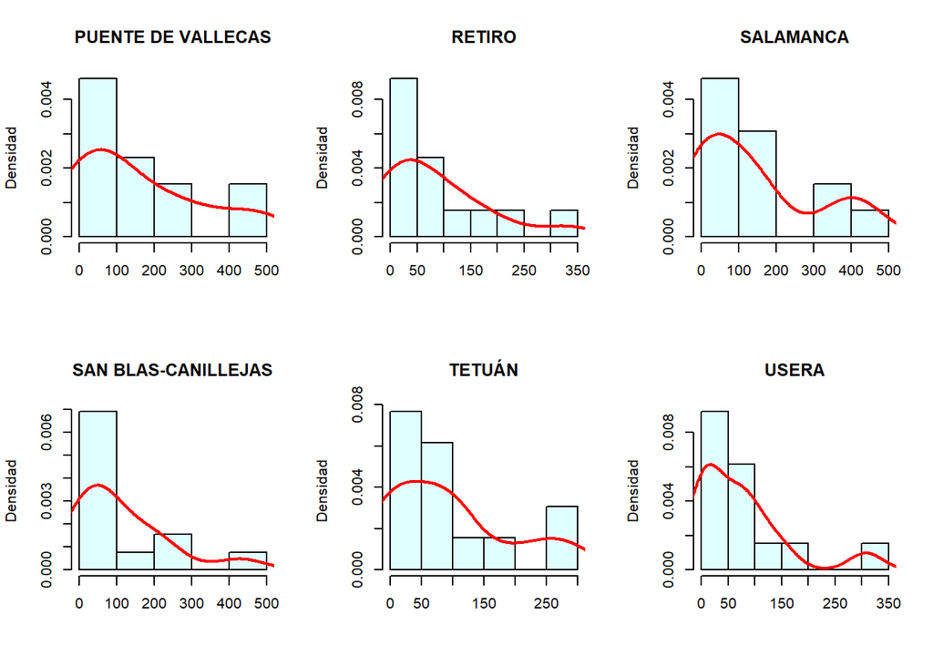

```r
par(mfrow=c(2,3))
hist(pca$`PUENTE DE VALLECAS`,freq = FALSE,col = "lightcyan",main = "PUENTE DE VALLECAS",xlab="",ylab="Densidad")
lines(density(pca$`PUENTE DE VALLECAS`),col="red",lwd=2)

hist(pca$RETIRO,freq = FALSE,col = "lightcyan",main = "RETIRO",xlab="",ylab="Densidad")
lines(density(pca$RETIRO),col="red",lwd=2)

hist(pca$SALAMANCA,freq = FALSE,col = "lightcyan",main = "SALAMANCA",xlab="",ylab="Densidad")
lines(density(pca$SALAMANCA),col="red",lwd=2)

hist(pca$`SAN BLAS-CANILLEJAS`,freq = FALSE,col = "lightcyan",main = "SAN BLAS-CANILLEJAS",xlab="",ylab="Densidad")
lines(density(pca$`SAN BLAS-CANILLEJAS`,),col="red",lwd=2)

hist(pca$TETUÁN,freq = FALSE,col = "lightcyan",main = "TETUÁN",xlab="",ylab="Densidad")
lines(density(pca$TETUÁN),col="red",lwd=2)

hist(pca$USERA,freq = FALSE,col = "lightcyan",main = "USERA",xlab="",ylab="Densidad")
lines(density(pca$USERA),col="red",lwd=2)
```

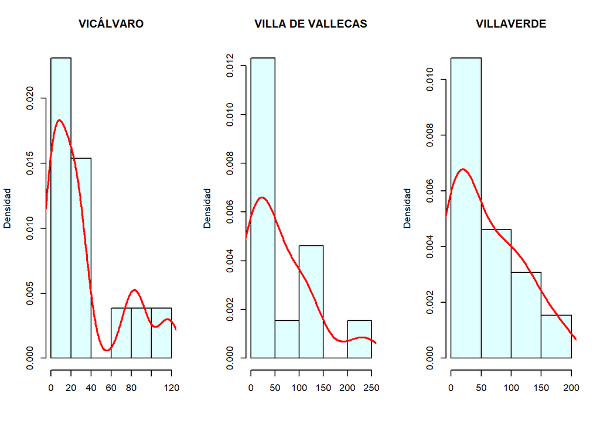

```r
par(mfrow=c(1,3))
hist(pca$VICÁLVARO,freq = FALSE,col = "lightcyan",main = "VICÁLVARO",xlab="",ylab="Densidad")
lines(density(pca$VICÁLVARO),col="red",lwd=2)

hist(pca$`VILLA DE VALLECAS`,freq = FALSE,col = "lightcyan",main = "VILLA DE VALLECAS",xlab="",ylab="Densidad")
lines(density(pca$`VILLA DE VALLECAS`),col="red",lwd=2)


hist(pca$VILLAVERDE,freq = FALSE,col = "lightcyan",main = "VILLAVERDE",xlab="",ylab="Densidad")
lines(density(pca$VILLAVERDE),col="red",lwd=2)
```

## Correlaciones

```r
cor(pca[,1:20])
```

```
##                     ARGANZUELA   BARAJAS CARABANCHEL    CENTRO CHAMARTÍN
## ARGANZUELA           1.0000000 0.8208938   0.9444732 0.9417764 0.9689399
## BARAJAS              0.8208938 1.0000000   0.9136064 0.8369769 0.8687098
## CARABANCHEL          0.9444732 0.9136064   1.0000000 0.8717577 0.9121298
## CENTRO               0.9417764 0.8369769   0.8717577 1.0000000 0.9729792
## CHAMARTÍN            0.9689399 0.8687098   0.9121298 0.9729792 1.0000000
## CHAMBERÍ             0.8947466 0.8605012   0.8815079 0.9082355 0.8773841
## CIUDAD LINEAL        0.9298288 0.9027458   0.9559757 0.8680570 0.8923665
## FUENCARRAL-EL PARDO  0.9587983 0.9277228   0.9842813 0.8981786 0.9459998
## HORTALEZA            0.7214482 0.9374482   0.8407674 0.7466108 0.7493108
## LATINA               0.9190430 0.9531453   0.9849585 0.8549390 0.9068220
## MONCLOA-ARAVACA      0.9747071 0.8808261   0.9595473 0.9039294 0.9416114
## MORATALAZ            0.9813764 0.8687369   0.9656962 0.9020331 0.9605583
## PUENTE DE VALLECAS   0.9589370 0.9030037   0.9575752 0.9199051 0.9502226
## RETIRO               0.9712917 0.7013109   0.8755332 0.9001901 0.9217575
## SALAMANCA            0.9484063 0.8467703   0.8782591 0.9785041 0.9664303
## SAN BLAS-CANILLEJAS  0.8758258 0.9401287   0.9355572 0.8616739 0.8675584
## TETUÁN               0.9348395 0.8189128   0.8800502 0.9780892 0.9340777
## USERA                0.8282478 0.8812195   0.9121736 0.7811964 0.7900069
## VICÁLVARO            0.8831827 0.9162450   0.9550689 0.8283251 0.8535628
## VILLA DE VALLECAS    0.8519273 0.9428551   0.9116368 0.8782199 0.8685847
##                      CHAMBERÍ CIUDAD LINEAL FUENCARRAL-EL PARDO HORTALEZA
## ARGANZUELA          0.8947466     0.9298288           0.9587983 0.7214482
## BARAJAS             0.8605012     0.9027458           0.9277228 0.9374482
## CARABANCHEL         0.8815079     0.9559757           0.9842813 0.8407674
## CENTRO              0.9082355     0.8680570           0.8981786 0.7466108
## CHAMARTÍN           0.8773841     0.8923665           0.9459998 0.7493108
## CHAMBERÍ            1.0000000     0.9416924           0.8846053 0.8550897
## CIUDAD LINEAL       0.9416924     1.0000000           0.9555789 0.8581541
## FUENCARRAL-EL PARDO 0.8846053     0.9555789           1.0000000 0.8336187
## HORTALEZA           0.8550897     0.8581541           0.8336187 1.0000000
## LATINA              0.8805237     0.9573459           0.9843412 0.8612010
## MONCLOA-ARAVACA     0.8989355     0.9593790           0.9850892 0.7934029
## MORATALAZ           0.8623903     0.9391957           0.9862435 0.7583115
## PUENTE DE VALLECAS  0.8971692     0.9706413           0.9648826 0.8140892
## RETIRO              0.8054493     0.8617459           0.8847402 0.5845388
## SALAMANCA           0.9449125     0.9039909           0.8986280 0.7716304
## SAN BLAS-CANILLEJAS 0.9563906     0.9770705           0.9244765 0.9243078
## TETUÁN              0.9433314     0.9062357           0.8822686 0.7592716
## USERA               0.9067457     0.9530077           0.8752328 0.9214074
```

[output cut: 50 more lines]

```
## CHAMBERÍ            0.9000682         0.9532030
## CIUDAD LINEAL       0.9573953         0.9474908
## FUENCARRAL-EL PARDO 0.9584509         0.9002033
## HORTALEZA           0.8878273         0.9227032
## LATINA              0.9515539         0.9231246
## MONCLOA-ARAVACA     0.9372861         0.8715883
## MORATALAZ           0.9202034         0.8583261
## PUENTE DE VALLECAS  0.9119268         0.9224335
## RETIRO              0.7753534         0.7478766
## SALAMANCA           0.8268153         0.9055620
## SAN BLAS-CANILLEJAS 0.9469278         0.9909279
## TETUÁN              0.8442179         0.9120771
## USERA               0.9172120         0.9498270
## VICÁLVARO           1.0000000         0.9230960
## VILLA DE VALLECAS   0.9230960         1.0000000
```

podemos observar que hay una correlación de casi uno entre los distritos VILLA DE VALLECAS y SAN BLAS-CANILLEJAS y también entre los distritos MORATALAZ y FUENCARRAL-EL PARDO